# Self-Driving Car Engineer Nanodegree

## Project: Build a Traffic Sign Recognition Classifier

This project builds and trains a neural network to identify 43 different German traffic signs.

All files for this project can be found at https://github.com/travis-k/CarND.git

## Step 0: Load The Data

```python
# Load pickled data
import pickle
from sklearn.utils import shuffle

# All images are 32x32, so no resizing is necessary

# Loading data provided by Udacity
training_file = 'sign_data/train.p'
validation_file='sign_data/valid.p'
testing_file = 'sign_data/test.p'

with open(training_file, mode='rb') as f:
    train = pickle.load(f)
with open(validation_file, mode='rb') as f:
    valid = pickle.load(f)
with open(testing_file, mode='rb') as f:
    test = pickle.load(f)

X_train, y_train = train['features'], train['labels']
X_valid, y_valid = valid['features'], valid['labels']
X_test, y_test = test['features'], test['labels']

# Shuffling the training data
X_train, y_train = shuffle(X_train, y_train)

# Ensuring there are no issues with data sizes
assert(len(X_train) == len(y_train))
assert(len(X_valid) == len(y_valid))
assert(len(X_test) == len(y_test))
```

## Step 1: Dataset Summary & Exploration

The pickled data is a dictionary with 4 key/value pairs:

- `'features'` is a 4D array containing raw pixel data of the traffic sign images, (num examples, width, height, channels).
- `'labels'` is a 1D array containing the label/class id of the traffic sign. The file `signnames.csv` contains id -> name mappings for each id.
- `'sizes'` is a list containing tuples, (width, height) representing the original width and height the image.
- `'coords'` is a list containing tuples, (x1, y1, x2, y2) representing coordinates of a bounding box around the sign in the image. **THESE COORDINATES ASSUME THE ORIGINAL IMAGE. THE PICKLED DATA CONTAINS RESIZED VERSIONS (32 by 32) OF THESE IMAGES**

### Providing a Basic Summary of the Data Set Using Python and Numpy

This section simply identifies the sizes of the data sets and prints them out.

```python
import numpy as np

# Information about the data set
n_train = len(X_train)
n_valid = len(X_valid)
n_test = len(X_test)
image_shape = X_train[0].shape
n_classes = len(np.unique(y_train))

print("\nPreprocessing:")
print("Number of training examples =", n_train)
print("Number of validation examples =", n_valid)
print("Number of testing examples =", n_test)
print("Image data shape =", image_shape)
print("Number of classes =", n_classes)
```

```
Preprocessing:
Number of training examples = 34799
Number of validation examples = 4410
Number of testing examples = 12630
Image data shape = (32, 32, 3)
Number of classes = 43
```

### Include an exploratory visualization of the dataset

Here, I plot an example of each of the 43 different signs. I also plot a graph which shows how many of each sign are in the training set.

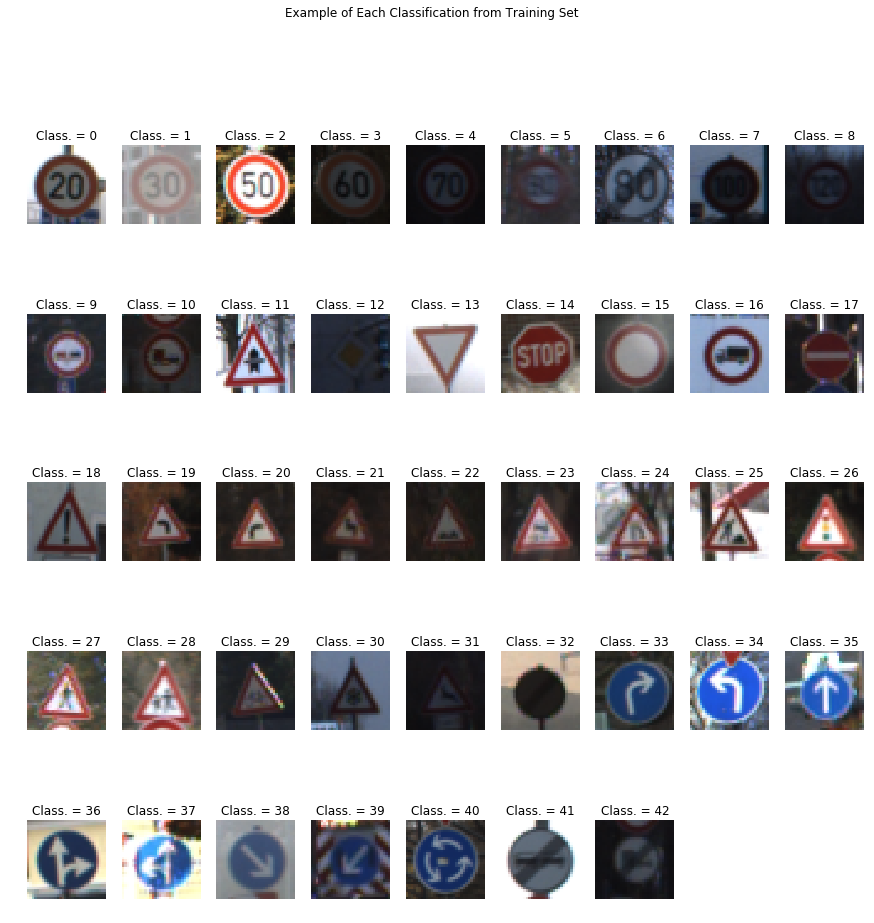

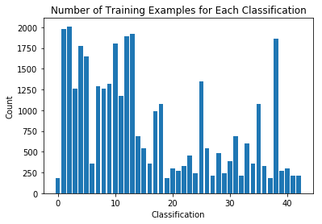

```python
# Displaying a random sign from the training set, and printing its classification
import random
import matplotlib.pyplot as plt

%matplotlib inline

[classes, idx, counts] = np.unique(y_train, return_index=True, return_counts=True)

plt.figure(num=1,figsize=(15,15))
plt.suptitle('Example of Each Classification from Training Set')
for i in range(1,44):
    image = X_train[idx[i-1]].squeeze()
    plt.subplot(5,9, i) # sets the number of feature maps to show on each row and column
    plt.title('Class. = ' + str(i-1)) # displays the feature map number
    plt.axis('off')
    plt.imshow(image)

plt.figure(num=2)
plt.bar(classes, counts)
plt.ylabel('Count')
plt.xlabel('Classification')
plt.title('Number of Training Examples for Each Classification')
plt.show()
```

## Step 2: Design and Test a Model Architecture

### Pre-process the Data Set (normalization, grayscale, etc.)

Use the code cell (or multiple code cells, if necessary) to implement the first step of your project.

```python
### Preprocess the data here. Preprocessing steps could include normalization, converting to grayscale, etc.
### Feel free to use as many code cells as needed.
import numpy as np

def normalize(x):
    return x/127.5 - 1.0

def grayscale(rgb):

    r, g, b = rgb[:,:,:,0], rgb[:,:,:,1], rgb[:,:,:,2]
    gray = 0.2989 * r + 0.5870 * g + 0.1140 * b

    return np.expand_dims(gray, axis=-1)

# Normalizing data from (0,255) to (-1,1)
X_train = normalize(X_train)
X_valid = normalize(X_valid)
X_test = normalize(X_test)

# Converting to grayscale (Going from depth of 3 to 1)
X_train = grayscale(X_train)
X_valid = grayscale(X_valid)
X_test = grayscale(X_test)
```

### Model Architecture

My "inception" neural network is based off of the inception modules explained in the Udacity lessons on deep learning. It is also based on the archiceture outlined in this article (https://hacktilldawn.com/2016/09/25/inception-modules-explained-and-implemented/), albiet with some changes.

The architecture features two inception modules, followed by two fully-connected layers. When training, the first fully-connected layer has dropout. The number of feature maps and the depths of the layers were reduced significantly, as their sizes were restricted by memory issues on the training computer.

The first inception module is as follows, with the input as 32x32x1 and the output concatenation 24 32x32 feature maps:

- Input -> 1x1 convolution (6 32x32 feature maps) -> concatenation
- Input -> 1x1 convolution (3 32x32 feature maps) -> 3x3 convolution (6 32x32 feature maps) -> concatenation
- Input -> 1x1 convolution (3 32x32 feature maps) -> 5x5 convolution (6 32x32 feature maps) -> concatenation
- Input -> 3x3 max pooling (1 32x32 feature map) -> 1x1 convolution (6 32x32 feature maps) -> concatenation

The second is similar to the first with the input 24 32x32 feature maps from the previous module, and the output a flattened concatenation of 48 32x32 feature maps, resulting in a shape of 1x49152:

- Input -> 1x1 convolution (12 32x32 feature maps) -> flattened concatenation
- Input -> 1x1 convolution (3 32x32 feature maps) -> 3x3 convolution (12 32x32 feature maps) -> flattened concatenation
- Input -> 1x1 convolution (3 32x32 feature maps) -> 5x5 convolution (12 32x32 feature maps) -> flattened concatenation
- Input -> 3x3 max pooling (24 32x32 feature maps) -> 1x1 convolution (12 32x32 feature maps) -> flattened concatenation

Then the first fully connected layer, with the input the 1x49152 concatenation from the previous layer, and the output 1x128

- Input -> ReLU (with dropout for training)

Then the final layer, with a 1x128 input and a 1x43 output,

- Input -> output (logits)

```python
def inception(x, drop):

    # Values for the random distribution of initial weights
    mu = 0
    sigma = 0.1

    # These parameters define the number of feature maps and the depth of the layers, and they are relatively
    # small due to memory constraints on the training computer
    map1 = 6
    map2 = 12
    reduce1x1 = 3
    num_fc1 = 128
    num_fc2 = 43
    img_size = 32

    # This model follows loosely from the following article:
    # https://hacktilldawn.com/2016/09/25/inception-modules-explained-and-implemented/

    # Both inception modules have the following components:
    # Input -> 1x1 convolution -> concatenation
    # Input -> 1x1 convolution -> 3x3 convolution -> concatenation
    # Input -> 1x1 convolution -> 5x5 convolution -> concatenation
    # Input -> 3x3 max pooling -> 1x1 convolution -> concatenation

    # Inception module 1
    W_conv1_1x1_1 = tf.Variable(tf.truncated_normal(shape=(1,1,1,map1), mean = mu, stddev = sigma))
    b_conv1_1x1_1 = tf.Variable(tf.zeros(map1))

    W_conv1_1x1_2 = tf.Variable(tf.truncated_normal(shape=(1,1,1,reduce1x1), mean = mu, stddev = sigma))
    b_conv1_1x1_2 = tf.Variable(tf.zeros(reduce1x1))

    W_conv1_1x1_3 = tf.Variable(tf.truncated_normal(shape=(1,1,1,reduce1x1), mean = mu, stddev = sigma))
    b_conv1_1x1_3 = tf.Variable(tf.zeros(reduce1x1))

    W_conv1_3x3 = tf.Variable(tf.truncated_normal(shape=(3,3,reduce1x1,map1), mean = mu, stddev = sigma))
    b_conv1_3x3 = tf.Variable(tf.zeros(map1))

    W_conv1_5x5 = tf.Variable(tf.truncated_normal(shape=(5,5,reduce1x1,map1), mean = mu, stddev = sigma))
    b_conv1_5x5 = tf.Variable(tf.zeros(map1))

    W_conv1_1x1_4= tf.Variable(tf.truncated_normal(shape=(1,1,1,map1), mean = mu, stddev = sigma))
    b_conv1_1x1_4= tf.Variable(tf.zeros(map1))

    conv1_1x1_1 = tf.nn.conv2d(x, W_conv1_1x1_1, strides=[1, 1, 1, 1], padding='SAME') + b_conv1_1x1_1
    conv1_1x1_2 = tf.nn.relu(tf.nn.conv2d(x, W_conv1_1x1_2, strides=[1, 1, 1, 1], padding='SAME') + b_conv1_1x1_2)
    conv1_1x1_3 = tf.nn.relu(tf.nn.conv2d(x, W_conv1_1x1_3, strides=[1, 1, 1, 1], padding='SAME') + b_conv1_1x1_3)
    conv1_3x3 = tf.nn.conv2d(conv1_1x1_2, W_conv1_3x3, strides=[1, 1, 1, 1], padding='SAME') + b_conv1_3x3
    conv1_5x5 = tf.nn.conv2d(conv1_1x1_3, W_conv1_5x5, strides=[1, 1, 1, 1], padding='SAME') + b_conv1_5x5
    maxpool1 = tf.nn.max_pool(x,ksize=[1,3,3,1],strides=[1,1,1,1],padding='SAME')
    conv1_1x1_4 = tf.nn.relu(tf.nn.conv2d(maxpool1, W_conv1_1x1_4, strides=[1, 1, 1, 1], padding='SAME') + b_conv1_1x1_4)

    # Concatenation of all feature maps, with ReLU
    inception1 = tf.nn.relu(tf.concat([conv1_1x1_1,conv1_3x3,conv1_5x5,conv1_1x1_4],3), name='inception1')

    #Inception Module2
    W_conv2_1x1_1 = tf.Variable(tf.truncated_normal(shape=(1,1,4*map1,map2), mean = mu, stddev = sigma))
    b_conv2_1x1_1 = tf.Variable(tf.zeros(map2))

    W_conv2_1x1_2 = tf.Variable(tf.truncated_normal(shape=(1,1,4*map1,reduce1x1), mean = mu, stddev = sigma))
    b_conv2_1x1_2 = tf.Variable(tf.zeros(reduce1x1))

    W_conv2_1x1_3 = tf.Variable(tf.truncated_normal(shape=(1,1,4*map1,reduce1x1), mean = mu, stddev = sigma))
    b_conv2_1x1_3 = tf.Variable(tf.zeros(reduce1x1))

    W_conv2_3x3 = tf.Variable(tf.truncated_normal(shape=(3,3,reduce1x1,map2), mean = mu, stddev = sigma))
    b_conv2_3x3 = tf.Variable(tf.zeros(map2))

    W_conv2_5x5 = tf.Variable(tf.truncated_normal(shape=(5,5,reduce1x1,map2), mean = mu, stddev = sigma))
    b_conv2_5x5 = tf.Variable(tf.zeros(map2))

    W_conv2_1x1_4= tf.Variable(tf.truncated_normal(shape=(1,1,4*map1,map2), mean = mu, stddev = sigma))
    b_conv2_1x1_4= tf.Variable(tf.zeros(map2))

    conv2_1x1_1 = tf.nn.conv2d(inception1, W_conv2_1x1_1, strides=[1, 1, 1, 1], padding='SAME') + b_conv2_1x1_1
    conv2_1x1_2 = tf.nn.relu(tf.nn.conv2d(inception1, W_conv2_1x1_2, strides=[1, 1, 1, 1], padding='SAME') + b_conv2_1x1_2)
    conv2_1x1_3 = tf.nn.relu(tf.nn.conv2d(inception1, W_conv2_1x1_3, strides=[1, 1, 1, 1], padding='SAME') + b_conv2_1x1_3)
    conv2_3x3 = tf.nn.conv2d(conv2_1x1_2, W_conv2_3x3, strides=[1, 1, 1, 1], padding='SAME') + b_conv2_3x3
    conv2_5x5 = tf.nn.conv2d(conv2_1x1_3, W_conv2_5x5, strides=[1, 1, 1, 1], padding='SAME') + b_conv2_5x5
    maxpool2 = tf.nn.max_pool(inception1,ksize=[1,3,3,1],strides=[1,1,1,1],padding='SAME')
    conv2_1x1_4 = tf.nn.relu(tf.nn.conv2d(maxpool2, W_conv2_1x1_4, strides=[1, 1, 1, 1], padding='SAME') + b_conv2_1x1_4)

    # Concatenation of all feature maps, with ReLU
    inception2 = tf.nn.relu(tf.concat([conv2_1x1_1,conv2_3x3,conv2_5x5,conv2_1x1_4],3), name='inception2')

    # Flattening
    inception2_flat = tf.reshape(inception2,[-1,img_size*img_size*4*map2])

    # These are the two fully connected layers, the first of which has dropout when training
    W_fc1 = tf.Variable(tf.truncated_normal(shape=(img_size*img_size*(4*map2),num_fc1), mean = mu, stddev = sigma))
    b_fc1 = tf.Variable(tf.zeros(num_fc1))

    h_fc1 =tf.nn.dropout(tf.nn.relu(tf.matmul(inception2_flat,W_fc1)+b_fc1),drop)

    W_fc2 = tf.Variable(tf.truncated_normal(shape=(num_fc1,num_fc2), mean = mu, stddev = sigma))
    b_fc2 = tf.Variable(tf.zeros(num_fc2))

    logits = tf.matmul(h_fc1, W_fc2) + b_fc2

    return logits
```

### Training and Validating the Model

```python
import tensorflow as tf

def evaluate(X_data, y_data):
    num_examples = len(X_data)
    total_accuracy = 0
    sess = tf.get_default_session()
    for offset in range(0, num_examples, BATCH_SIZE):
        batch_x, batch_y = X_data[offset:offset+BATCH_SIZE], y_data[offset:offset+BATCH_SIZE]
        accuracy = sess.run(accuracy_operation, feed_dict={x: batch_x, y: batch_y, drop: 1.0})
        total_accuracy += (accuracy * len(batch_x))
    return total_accuracy / num_examples

EPOCHS = 15
BATCH_SIZE = 128

x = tf.placeholder(tf.float32, (None, 32, 32, 1))
y = tf.placeholder(tf.int32, (None))
drop = tf.placeholder(tf.float32)
one_hot_y = tf.one_hot(y, 43)

rate = 0.001

logits = inception(x, drop)

testing_images = tf.nn.softmax(logits)
cross_entropy = tf.nn.softmax_cross_entropy_with_logits(logits=logits, labels=one_hot_y)
loss_operation = tf.reduce_mean(cross_entropy)
optimizer = tf.train.AdamOptimizer(learning_rate = rate)
training_operation = optimizer.minimize(loss_operation)

correct_prediction = tf.equal(tf.argmax(logits, 1), tf.argmax(one_hot_y, 1))
accuracy_operation = tf.reduce_mean(tf.cast(correct_prediction, tf.float32))
saver = tf.train.Saver()
```

```python
# Training, validating, testing and saving the model
with tf.Session() as sess:
    sess.run(tf.global_variables_initializer())
    num_examples = len(X_train)

    print("\nTraining...")
    print()
    for i in range(EPOCHS):
        X_train, y_train = shuffle(X_train, y_train)
        for offset in range(0, num_examples, BATCH_SIZE):
            end = offset + BATCH_SIZE
            batch_x, batch_y = X_train[offset:end], y_train[offset:end]
            sess.run(training_operation, feed_dict={x: batch_x, y: batch_y, drop: 0.5})

        train_accuracy = evaluate(X_train, y_train)
        validation_accuracy = evaluate(X_valid, y_valid)
        print("EPOCH {} ...".format(i+1))
        print("Train Accuracy = {:.3f}".format(train_accuracy))
        print("Validation Accuracy = {:.3f}".format(validation_accuracy))
        print()

    saver.save(sess, './incept')
    print("Model saved")
```

```
Training...

EPOCH 1 ...
Train Accuracy = 0.851
Validation Accuracy = 0.760

EPOCH 2 ...
Train Accuracy = 0.958
Validation Accuracy = 0.875

EPOCH 3 ...
Train Accuracy = 0.973
Validation Accuracy = 0.914

EPOCH 4 ...
Train Accuracy = 0.985
Validation Accuracy = 0.918

EPOCH 5 ...
Train Accuracy = 0.989
Validation Accuracy = 0.932

EPOCH 6 ...
Train Accuracy = 0.993
Validation Accuracy = 0.938

EPOCH 7 ...
Train Accuracy = 0.994
Validation Accuracy = 0.946

EPOCH 8 ...
Train Accuracy = 0.996
Validation Accuracy = 0.937

EPOCH 9 ...
Train Accuracy = 0.997
Validation Accuracy = 0.937

EPOCH 10 ...
Train Accuracy = 0.998
```

[output cut: 8 more lines]

```
Validation Accuracy = 0.940

EPOCH 13 ...
Train Accuracy = 0.999
Validation Accuracy = 0.949

EPOCH 14 ...
Train Accuracy = 0.999
Validation Accuracy = 0.943

EPOCH 15 ...
Train Accuracy = 0.999
Validation Accuracy = 0.946

Model saved
```

### Testing the model

Here, I test the model on the test set provided by Udacity.

```python
with tf.Session() as sess:
    sess.run(tf.global_variables_initializer())
    saver.restore(sess, './incept')


    test_accuracy = evaluate(X_test, y_test)
    print("Test Accuracy = {:.3f}".format(test_accuracy))
```

```
Test Accuracy = 0.935
```

## Step 3: Test a Model on New Images

Here, we test eight images of German traffic signs taken from Wikipedia. They are resized manually to 32x32, to be compatible with the neural network.

### Load and Output the Images

Note: The image_class vector is hard-coded in! These values match the images in the /outside_images/ folder.

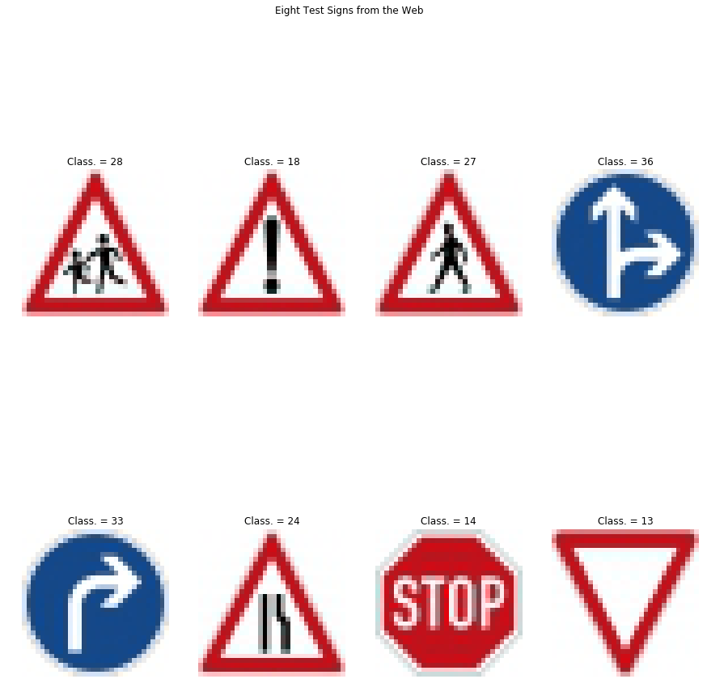

```python
import os
import matplotlib.image as mpimg

strImageIn = ["outside_images/" + x for x in os.listdir("outside_images/")]
image_class = [28, 18, 27, 36, 33, 24, 14, 13]

plt.figure(num=3,figsize=(15,15))
plt.suptitle('Eight Test Signs from the Web')
for i in range(1,9):
    X_web = mpimg.imread(strImageIn[i-1])
    image = X_web.squeeze()
    plt.subplot(2,4, i) # sets the number of feature maps to show on each row and column
    plt.title('Class. = ' + str(image_class[i-1])) # displays the feature map number
    plt.axis('off')
    plt.imshow(image)
```

### Predict the Sign Type for Each Image

Here I loop over the above 8 images and try to identify them, using the trained neural network. I then print out the top 5 softmax values for each sign, with their corresponding classification. I also create bar graphs for visualization (one for each sign).

```
Test image 0 (true classification: 28)
Top five softmaxes: [  9.99887109e-01   1.07315296e-04   3.37488541e-06   1.03428260e-06
   9.39073061e-07]
Corresponding classifications: [28 20 23  3 19]
```

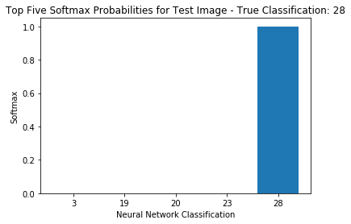

```
Test image 1 (true classification: 18)
Top five softmaxes: [  1.00000000e+00   6.22740952e-15   1.48081873e-19   8.59844634e-21
   1.75191034e-23]
Corresponding classifications: [18 11 25 26 33]
```

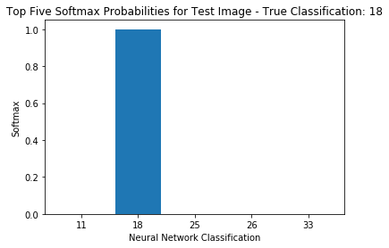

```
Test image 2 (true classification: 27)
Top five softmaxes: [  9.99994636e-01   5.30809211e-06   1.73529280e-08   4.33902803e-10
   3.29196115e-10]
Corresponding classifications: [11 27 18 20 30]
```

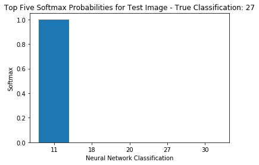

```
Test image 3 (true classification: 36)
Top five softmaxes: [  5.36028206e-01   4.63781387e-01   1.61962686e-04   2.34662930e-05
   3.54449617e-06]
Corresponding classifications: [36 25 22 38 26]
```

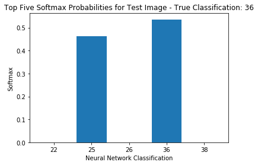

```
Test image 4 (true classification: 33)
Top five softmaxes: [  9.99992728e-01   5.32512331e-06   1.02319916e-06   8.24889582e-07
   1.72710472e-07]
Corresponding classifications: [33  4  1  5 37]
```

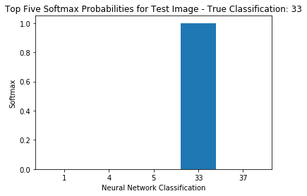

```
Test image 5 (true classification: 24)
Top five softmaxes: [  9.99795973e-01   1.92535284e-04   5.98230417e-06   5.43814213e-06
   1.39649515e-07]
Corresponding classifications: [24 19 11 21 18]
```

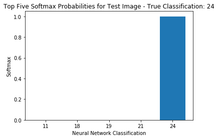

```
Test image 6 (true classification: 14)
Top five softmaxes: [ 0.98133069  0.00616247  0.00489482  0.00258557  0.00219267]
Corresponding classifications: [25  1  3 18 33]
```

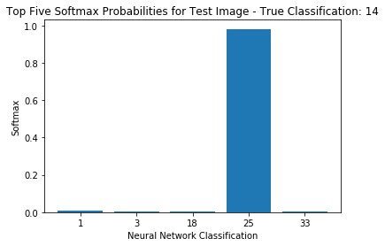

```
Test image 7 (true classification: 13)
Top five softmaxes: [  1.00000000e+00   5.84298588e-18   1.66925469e-33   1.06959305e-33
   4.47708117e-35]
Corresponding classifications: [13 35  9 12 33]
```

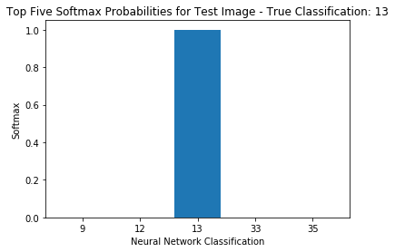

```python
with tf.Session() as sess:
    sess.run(tf.global_variables_initializer())
    saver.restore(sess, './incept')

    image_num = 0
    plt_num = 4
    successes = 0

    # Looping over the 8 images in the directory
    for image in strImageIn:

        # Reading them in and formatting the arrays correctly
        X_test_map_img = mpimg.imread(image)
        X_test_map = np.expand_dims(X_test_map_img, axis=0)

        # Normalizing data from (0,255) to (-1,1)
        X_test_map = normalize(X_test_map)

        # Converting to grayscale (Going from depth of 3 to 1)
        X_test_map = grayscale(X_test_map)

        # Finding the softmax probabilities
        logits2 = sess.run(testing_images, feed_dict={x: X_test_map, drop: 1.0})

        # Getting the top five softmax results
        topKV = sess.run(tf.nn.top_k(logits2, k=5))

        # Reformatting the above topKV data to make plotting easier
        classes = topKV[1].squeeze();
        softs = topKV[0].squeeze();
        idx = np.argsort(classes)

        # Printing the above data as requested by Udacity
        print('\nTest image ' + str(image_num) + ' (true classification: ' + str(image_class[image_num]) + ')')
        print('Top five softmaxes: ' + str(softs))
        print('Corresponding classifications: ' + str(classes))

        # Plotting bar graphs showing the top five softmax results for each of the 8 web images
        plt.figure(num=plt_num)
        plt.xticks(range(0,6), classes[idx])
        plt.bar(np.array(range(0,5)), softs[idx])
        plt.ylabel('Softmax')
        plt.xlabel('Neural Network Classification')
        plt.title('Top Five Softmax Probabilities for Test Image - True Classification: ' + str(image_class[image_num]))
        plt.show()

        # If we classified this web image correctly, we add it to a tally
        if classes[0] == image_class[image_num]:
            successes += 1

        image_num += 1
        plt_num += 1
```

### Analyze Performance

Here, I calculate the accuracy of the above test by using the "successes" tally from the above loop, and the total number of signs (8).

```python
    # Finding the accuracy over the web images
    web_image_accuracy = successes/8

    print('\nAccuracy over the images aquired on the web: ' + str(web_image_accuracy))
```

```
Accuracy over the images aquired on the web: 0.75
```

## Step 4: Visualize the Neural Network's State with Test Images

**This section doesn't run for me in Jupyter Notebook, but does run in my .py file available on my Github.**

```python
def outputFeatureMap(image_input, tf_activation, activation_min=-1, activation_max=-1 ,plt_num=3):
    # Here make sure to preprocess your image_input in a way your network expects
    # with size, normalization, ect if needed
    # image_input =
    # Note: x should be the same name as your network's tensorflow data placeholder variable
    # If you get an error tf_activation is not defined it maybe having trouble accessing the variable from inside a function

    # image_input: the test image being fed into the network to produce the feature maps
    # tf_activation: should be a tf variable name used during your training procedure that represents the calculated state of a specific weight layer
    # activation_min/max: can be used to view the activation contrast in more detail, by default matplot sets min and max to the actual min and max values of the output
    # plt_num: used to plot out multiple different weight feature map sets on the same block, just extend the plt number for each new feature map entry

    activation = tf_activation.eval(session=sess,feed_dict={x : image_input, drop: 1})
    featuremaps = activation.shape[3]
    plt.figure(plt_num, figsize=(15,15))
    for featuremap in range(featuremaps):
        plt.subplot(6,8, featuremap+1) # sets the number of feature maps to show on each row and column
        plt.title('FeatureMap ' + str(featuremap)) # displays the feature map number
        if activation_min != -1 & activation_max != -1:
            plt.imshow(activation[0,:,:, featuremap], interpolation="nearest", vmin =activation_min, vmax=activation_max)
        elif activation_max != -1:
            plt.imshow(activation[0,:,:, featuremap], interpolation="nearest", vmax=activation_max)
        elif activation_min !=-1:
            plt.imshow(activation[0,:,:, featuremap], interpolation="nearest", vmin=activation_min)
        else:
            plt.imshow(activation[0,:,:, featuremap], interpolation="nearest")

with tf.Session() as sess:
    sess.run(tf.global_variables_initializer())
    saver.restore(sess, './incept')

    # Outputting feature maps for both inception layers on a test image to visualize
    outputFeatureMap(X_test_map, sess.graph.get_tensor_by_name('inception1:0'), activation_min=-1, activation_max=-1 ,plt_num=plt_num)
    outputFeatureMap(X_test_map, sess.graph.get_tensor_by_name('inception2:0'), activation_min=-1, activation_max=-1 ,plt_num=plt_num+1)
```